# On the Generation of Event Records

Don Li

25 June 2018

```r
library( data.table )
library( ggplot2 )
# The CAB package is for the ks() function, which computes the Kolmogorov-Smirnov statistic.
# R has a built-in function for the KS statistic, ks.test()
library( CAB )
library( grid )
library( gridExtra )
# Set up some parallel processing to make things go faster
library( foreach ); library( doParallel )
cluster_up = FALSE
if ( !cluster_up ){
    cl = makeCluster(5)
    registerDoParallel(cl)
    cluster_up = TRUE
}
```

This document contains examples of doing parameter estimation for response generating models from multiple perspectives; Bayesian, Frequentist, and a non-statistical approach. We use a toy example that of a model that represents an organism that generates responses at a constant rate, but sometimes engages in some extraneous behaviours before returning to respond at a constant rate. The schedule is an FI schedule with a hold on the reinforcer delivery for inter-response times that are below some threshold.

Note that the code for making the plots are not shown. To see this code, refer to the .rmd file that generated this document.

The model is shown below:

```r
double_exp_model = function( mean_irt, long_irt_shift, short_prob, mean_prp ){

    max_time = 10000
    event_record = data.table( time = rep( NaN, 100000 ), event = rep( NaN, 100000 ) )
    n_events = 1L; n_resps = 1L; n_rfts = 1L

    event_record_headers = c("time", "event")

    rft = FALSE; last_rft_time = 0
    time_ = 0

    # Run the experiment
    while ( time_ < max_time ){
        if ( rft ){
            resp_latency = rchisq( 1, mean_prp ) + 0.5
            rft = FALSE
        } else{
            if ( runif(1) < short_prob ){
                resp_latency = rexp( 1, 1/mean_irt ) + 0.1
            } else{
                resp_latency = rexp( 1, 1/mean_irt ) + 0.1 + long_irt_shift
            }
        }
        time_ = time_ + resp_latency

        # End if time elapsed
        if ( time_ > max_time ) break

        # Record response; code 1 for responses
        set( event_record, i = n_events, j = event_record_headers, value = list( time_, 1 ) )
        n_events = n_events + 1L

        # Deliver reinforcer and arrange the next one
        if ( resp_latency > 4.5 & time_ - last_rft_time > 15 ){
            # Record reinforcer; code 10 for responses
            set( event_record, i = n_events, j = event_record_headers, value = list( time_, 10 ) )
            n_events = n_events + 1L
            rft = TRUE
            last_rft_time = time_
        }
    }
    # Return the event record
    event_record[ !is.na(time) ]
}
```

We note that the arranged inter-reinforcer interval (IRI) for the FI schedule is 15s, reinforcers are not delivered for repsonses with an inter-response time (IRT) of less than 4.5s, and the minimum IRT is 0.1s. The experiment terminates after 10000s.

The true parameters are shown in the chunk below:

```r
true_parameters = c( mean_irt = 1.5, long_irt_shift = 4, short_prob = 0.7, mean_prp = 5 )
```

Because the model generates an event record and because event records are complex, we are motivated to summarise the event records with a set of summary. Here, we are going to use the IRT distribution, the IRI distribution, and the PRP distribution. In our examples, we will use the IRTs and PRPs as dependent variables for fitting the model. The IRI distribution will be used as a post-fit variable, mostly as a sanity check. We will also trim top 1% of the the IRT/PRP/IRI distributions to make life easier.

```r
# Function to extract the dependent variables of interest
summary_statistics = function( event_record, iri = FALSE ){
    event_record[ , {
        temp_time = time
        rfts = which( event == 10 )
        prp_resp = rfts + 1

        # Skip responses separated by reinforcers
        temp_time[ rfts ] = NaN
        temp_time[ prp_resp ] = NaN
        irts = diff( temp_time )
        irts = irts[ !is.na(irts) ]
        irts = irts[ irts < quantile(irts, 0.99) ]

        prps = time[ prp_resp ] - time[ rfts ]
        prps = prps[ !is.na(prps) ]
        prps = prps[ prps < quantile(prps, 0.99) ]

        if ( iri ){
            iris = diff( time[ event == 10 ] )
            iris = iris[ iris < quantile(iris, 0.99) ]
            return( list( irts = list(irts), iris = list(iris), prps = list(prps) ) )
        } else{
            return( list( irts = list(irts), prps = list(prps) ) )
        }
    } ]
}
```

Now, we simulate some data from the model. These will be our “observed” data.

```r
set.seed(1)
observed_event_record = do.call( double_exp_model, as.list(true_parameters) )
```

Let’s do some exploratory analysis of the data. First, we will look at a cumulative record to see if things make sense (Figure 1). As we can see, reinforcers were never delivered in the steepest parts of the cumulative record (i.e., when the model was emitting fast IRTs).

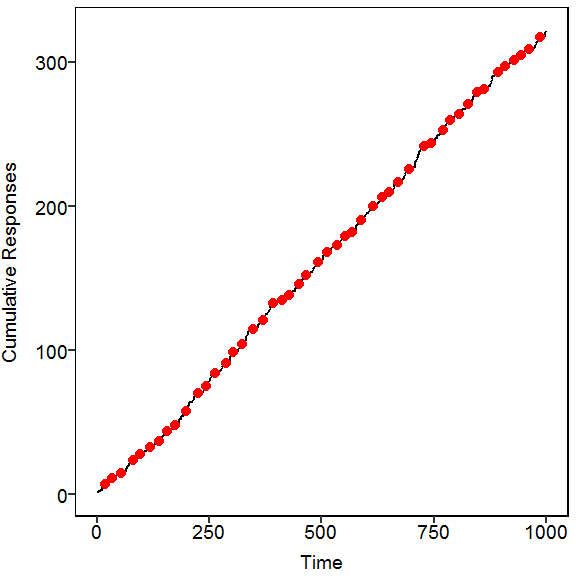

Table 1 summarises the frequencies in the event record.

```
##   Responses Reinforcers
##        3086         465
```

The following figures show the observed IRT, PRP, and IRI distributions.

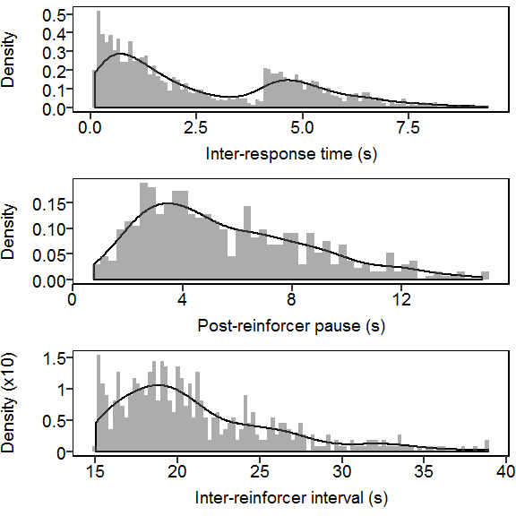

Figure 2. Observed IRT and IRI distributions.

# Non-Statistical

We fit our toy example to the IRT and IRI distributions by minimising the two-sample Kolmogorov-Smirnov statistic for both variables. The two-sample KS statistic is a measure of poorness of fit for two distributions. When $KS=1$, there is no overlap between the distributions. When $KS=0$, there is complete overlap between the distributions everywhere.

The optimisation algorithm that we use essentially resamples preivously tried parameters and adds a bit of noise (determined by the bandwidth) to search around a bit. We combine all of the proposed solutions and then we take the best 1% for the IRT and IRIs. For real applications, it is best not to use this algorithm. Better to use something that has been well-validated, such as evolutionary algorithms, differential evolution, and the like.

This example takes about 3-4 minutes on my home computer.

```r
knitr::opts_chunk$set(cache = TRUE )

get_cost = function( parameters ){
    # If the parameters are out of bounds, set cost function to infinity.
    if ( any( parameters < 0 ) | parameters["short_prob"] > 1 ){
        return( c(parameters,Inf, Inf) )
    }

    # Run the model
    predicted_event_record = do.call( double_exp_model, as.list(parameters) )

    # Extract the IRT and IRI distributions
    predicted_variables = summary_statistics( predicted_event_record )
    # Calculate the KS for the IRTs and IRIs
    irt_ks = ks( predicted_variables$irts[[1]], observed_data$irts[[1]] )
    prp_ks = ks( predicted_variables$prps[[1]], observed_data$prps[[1]] )

    return_vector = c( parameters, irt_ks, prp_ks )
    print( return_vector )
    return_vector
}

if ( !"non_statistical.RData" %in% list.files("D:/Dropbox/Dropbox/Don/statistics_paper/statistics_notebook/") ){
    set.seed(4)
    # Run for 5000 iterations
    n_proposals = 5000

    # Set bandwidth for search
    bw = c( 1, 1.5, 0.2, 2 ); min_bw = bw*(0.99^200)

    storage = data.table( "mean_irt" = rep( NaN, n_proposals ) )

    for ( proposal in 1:n_proposals ){
        print( paste0( "Iteration ", proposal ) )
        if ( proposal == 1 ){
            new_proposal = true_parameters
            # I chose some random numbers for seeding
            new_proposal[] = c(2.5, 3, 0.5, 4 )
        } else if ( proposal < 1000 ){
            # Sample one of the previously tried parameters
                new_proposal = storage[ is.finite(irt_ks+prp_ks) ][ sample.int(.N,1), names(true_parameters), with = FALSE ]
                new_proposal = unlist( new_proposal )
        } else{
            # Sample one of the parameters that in the best 100 for the IRTs and the IRIs
            new_proposal = storage[ is.finite(irt_ks+prp_ks),{
                ranks = rank(irt_ks) + rank( prp_ks )
                .SD[ sample.int( .N, 1, prob = 1/ranks ), names( true_parameters ), with = F  ]
            } ]
            new_proposal = unlist( new_proposal )
        }
        # Add some noise to the parameters
        if ( proposal >= 1000 ){
            bw = bw*0.99
            bw = pmax( bw, min_bw )
        }
        new_proposal = runif( length(new_proposal), new_proposal-bw, new_proposal+bw  )
        names(new_proposal) = names( true_parameters )

        proposed_cost = get_cost( new_proposal )
        set( storage, i = proposal, j = c(names(true_parameters), "irt_ks", "prp_ks" ), value = as.list(proposed_cost) )
    }

    save( storage, file = "non_statistical.RData" )
} else{
    load( "non_statistical.RData" )
}
```

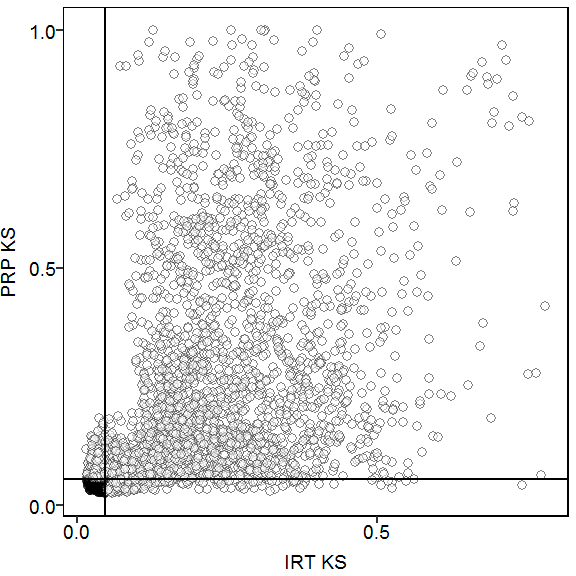

Figure 3. Geometry of the best solution.

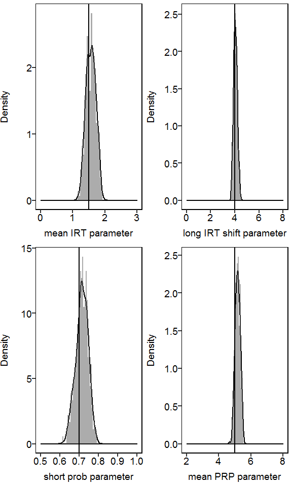

Figure 4. Plausible distributions

Now that we have fit the model and obtained our plausible distributions, we want to simulate data from the plausible distribution to see the predicted data.

```r
if( !"predicted_plausible.RData" %in% list.files() ){
    # Simulate 2000 event records for our predictions
    set.seed(1)
    simulate_parameters = plausible_distribution[ sample( 1:.N, 1000, replace = T ), names(true_parameters), with = F ]
    #Remember to change the .packages() if you are not using CAB2
    predicted_event_records = foreach( x = 1:1000, .packages = c("data.table", "CAB2")) %dopar% {
        parameters = simulate_parameters[x]
        predicted_event_record = do.call( double_exp_model, parameters )
        predicted_distributions = summary_statistics( predicted_event_record, iri = TRUE )
        # Precompute the density for the IRT and IRI distributions
        irt_density = density( predicted_distributions$irts[[1]], from = 0, n = 100 )
        prp_density = density( predicted_distributions$prps[[1]], from = 0, to = 25, n = 100 )
        iri_density = density( predicted_distributions$iris[[1]], from = 0, to = 75, n = 100 )
        list( id = x,
            irts_x = irt_density$x, irts_y = irt_density$y,
            iris_x = iri_density$x, iris_y = iri_density$y,
            prps_x = prp_density$x, prps_y = prp_density$y)
    }
    predicted_irts = rbindlist( lapply( predicted_event_records, function(x) as.data.table(x[c("id","irts_x","irts_y")]) ) )
    predicted_iris = rbindlist( lapply( predicted_event_records, function(x) as.data.table(x[c("id","iris_x","iris_y")]) ) )
    predicted_prps = rbindlist( lapply( predicted_event_records, function(x) as.data.table(x[c("id","prps_x","prps_y")]) ) )
    save( predicted_irts, predicted_iris, predicted_prps, file = "predicted_plausible.RData" )
} else{
    load( "predicted_plausible.RData" )
}
```

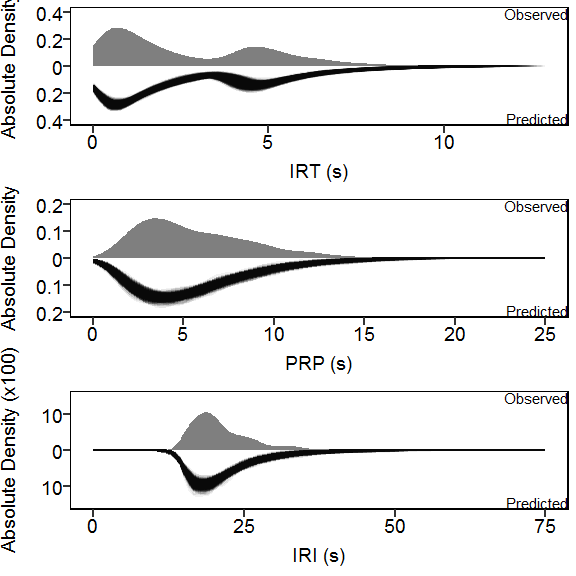

Figure 5. Non-Statistical Predictions

# Approximate likelihood inference

In this example, we fit our toy example to the data using an approximate likelihood technique, where we simulate the model to construct empirical likelihoods. Recall that the likelihood is the distribution of the data given the parameters. If we have the model, then we can simulate the likelihood by choosing a parameter value, repeatedly simulating the model, and then extracting the distribution of the variables of interest. The simulation of the likelihoods is done in the `simulate_likelihoods()` function.

Due to the error associated with simulating the likelihood, we have simulated the likelihood on a grid of parameters instead of using an optimisation algorithm. We then used a `loess()` to estimate the minimum.

We added the following constraints: * If any of the parameters were ouf of their defined boundaries, the likelihood was `Inf`. * If there was only one PRP, the likelihood was set to `Inf`. * If there was an `NA` in the approximate log likelihood, it was set to `Inf`. To simulate the likelihood, we simulated the model at the given parameters for 100 sessions. We then combined the IRT and IRIs across all of those sessions. Using the combined IRT and IRI distributions, we approximated the distribution with `density()` and then created a function using `approxfun()`. Following the Turner and Sederberg (2014) paper, we used the Epanechnikov kernel. Further, because of the error associated with the kernel density estimatior, we subtract the known minimiums from each of the latencies.

```r
simulate_likelihoods = function( parameters, double_exp_model, summary_statistics ){
    # Parameter constraits
    if ( any( parameters < 0 ) | parameters["short_prob"] > 1 ){
        return( c(parameters,Inf,Inf,Inf ) )
    }

    # Simulate 100 sessions
    # Remember to change the packages here if you are not using CAB2
    results = foreach( i = 1:5, .packages = c("data.table", "CAB2") ) %dopar%{
        results2 = lapply( 1:20, function(x){
            predicted_event_record = do.call( double_exp_model, as.list( parameters ) )
            predicted_variables = summary_statistics( predicted_event_record )
        } )
        rbindlist( results2[1] )
    }
    results = rbindlist( results )
    if ( length( results$prps[[1]] ) < 2 ){
        return( c(parameters,Inf,Inf,Inf) )
    }

    # Compute approximate likelihoods
    irt_density = density( ( unlist(results$irts)-0.1 ), kernel = "epanechnikov", from = 0 )
    irt_likelihood = approxfun( irt_density )
    prp_density = density( ( unlist(results$prps)-0.5 ), kernel = "epanechnikov", from = 0 )
    prp_likelihood = approxfun( prp_density )
    # # Use negative log likelihood
    irt_log_likelihood = sum( log( irt_likelihood( ( observed_data$irts[[1]]-0.1 ) ) ) )
    prp_log_likelihood = sum( log( prp_likelihood( ( observed_data$prps[[1]]-0.5 ) ) ) )

    # Return the joint likelihood
    sum_neg_log_likelihood = - (irt_log_likelihood + prp_log_likelihood)

    if ( is.na(sum_neg_log_likelihood) ) return( c(parameters,Inf, Inf, Inf ) )
    c( parameters, sum_neg_log_likelihood, irt_log_likelihood, prp_log_likelihood )
}
```

```r
if ( ! "likelihood_results.RData" %in% list.files() ){
    set.seed(2)

    param_matrix = data.table( expand.grid(
        mean_irt = seq( 0.5, 2.5, length.out = 10 ),
        long_irt_shift = seq( 2.5, 5.5, length.out = 10 ),
        short_prob = seq( 0.5, 0.9, length.out = 10 ),
        mean_prp = seq( 3.5, 6.5, length.out = 10 )
    ) )
    n_iterations = nrow( param_matrix )
    storage_likelihood = data.table( "mean_irt" = rep(NaN, n_iterations) )

    # Fit the model; this takes quite a long time.
    for ( i in 1:n_iterations ){
        print( paste0( "Iteration ", i ) )
        new_proposal = unlist(param_matrix[i])

        # Simulate likelihood
        new_likelihood = simulate_likelihoods( new_proposal, double_exp_model, summary_statistics )
        # Decrease bandwidth
        set( storage_likelihood, i = i, j = c(names(true_parameters), "likelihood", "irt", "prp" ), value = as.list(new_likelihood) )
    }
    save( storage_likelihood, file = "likelihood_results.RData" )
} else{
    load( "likelihood_results.RData" )
}

# Remove infinite values
storage_likelihood = storage_likelihood[ is.finite( likelihood ) ]
```

```r
smoothed_likelihood = loess( likelihood ~ mean_irt + long_irt_shift + short_prob, data = storage_likelihood )
storage_likelihood[ , predicted_likelihood := predict( smoothed_likelihood, storage_likelihood ) ]

predicted_mle = optim( true_parameters, function(x){
    d = as.data.table( as.list( x ) )
    predict( smoothed_likelihood, d )
} )
predicted_mle = data.table( V1 = predicted_mle$par, name = names(true_parameters), val = "Est" )
true_ = data.table( V1 = true_parameters, name = names( true_parameters ), val = "True" )
vline_dt = rbindlist( list(true_, predicted_mle) )
```

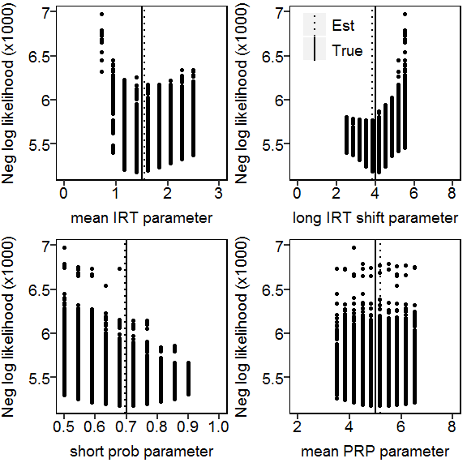

Figure 6. Approximate likelihood results

To generate predictions, we simulate the model 1000 times at our approximate maximum likelihood estimates. The predictions are shown in Figure 7.

```r
if( !"predicted_approx_likelihood.RData" %in% list.files() ){
    # Simulate 1000 event records for our predictions
    set.seed(1)
    simulate_parameters = transpose( predicted_mle[ , list(V1) ] ); names(simulate_parameters) = names(true_parameters)
    simulate_parameters = simulate_parameters[ rep( 1, 1000 ) ]
    #Remember to change the .packages() if you are not using CAB2
    predicted_event_records = foreach( x = 1:1000, .packages = c("data.table", "CAB2")) %dopar% {
        parameters = simulate_parameters[x]
        predicted_event_record = do.call( double_exp_model, parameters )
        predicted_distributions = summary_statistics( predicted_event_record, iri = TRUE )
        # Precompute the density for the IRT and IRI distributions
        irt_density = density( predicted_distributions$irts[[1]], from = 0, n = 100 )
        prp_density = density( predicted_distributions$prps[[1]], from = 0, to = 25, n = 100 )
        iri_density = density( predicted_distributions$iris[[1]], from = 0, to = 75, n = 100 )
        list( id = x,
            irts_x = irt_density$x, irts_y = irt_density$y,
            iris_x = iri_density$x, iris_y = iri_density$y,
            prps_x = prp_density$x, prps_y = prp_density$y)
    }
    predicted_irts = rbindlist( lapply( predicted_event_records, function(x) as.data.table(x[c("id","irts_x","irts_y")]) ) )
    predicted_iris = rbindlist( lapply( predicted_event_records, function(x) as.data.table(x[c("id","iris_x","iris_y")]) ) )
    predicted_prps = rbindlist( lapply( predicted_event_records, function(x) as.data.table(x[c("id","prps_x","prps_y")]) ) )
    save( predicted_irts, predicted_iris, predicted_prps, file = "predicted_approx_likelihood.RData" )
} else{
    load( "predicted_approx_likelihood.RData" )
}
```

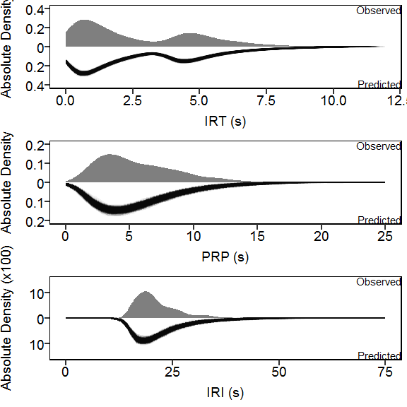

Figure 7. Approximate likelihood predictions

# Approximate Bayesian Computation

The following figure illustrates the relationships between the distribution of the data and the prior. Recall that the posterior is the probability of the parameters (from the prior) given the data (from the data). For continuous data, we use a threshold so that all of the data within the threshold is “close enough” to the observed data. The parameter values that fall within the tolerance region form the approximate posterior.

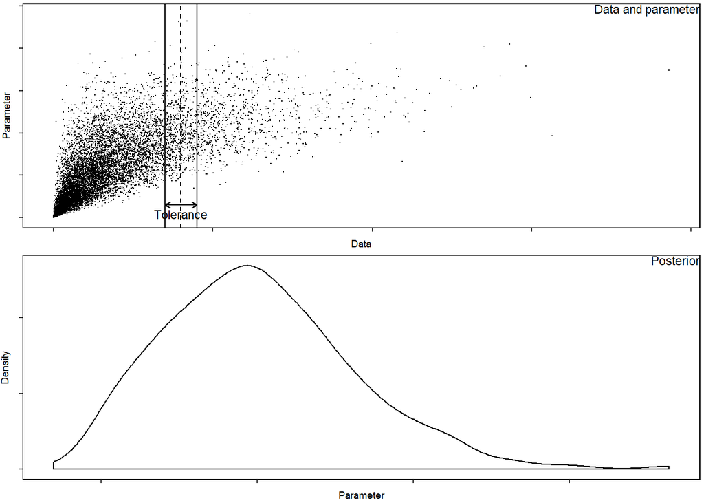

Here, we use a simple ABC-rejection algorithm. We need to:

- Define our priors (`sample_prior()`)
- Define the goodness of fit statistics for the IRT and IRI distributions (two-sample Kolmogorov-Smirnov statistic)
- Define thresholds for the IRT and IRI KS statistics. We used 0.06 because this seemed like a good compromise between the number of simulations we would have to do and the number of samples in our approximate posterior.

```r
rprior = function(n_samples){
    matrix( c(
        mean_irt = runif(n_samples, 0.5, 2.5 ),
        long_irt_shift = runif( n_samples,2,6 ),
        short_prob = runif( n_samples, 0.5, 0.9 ),
        mean_prp = runif( n_samples, 3, 7 )
    ), ncol = 4 )
}

threshold_irt = threshold_prp = 0.06
n_samples = 50000
sample_headers = c( names(true_parameters), "irt_ks", "prp_ks" )
n_parallel = 5
set.seed(3)
joint_samples = data.table( rprior(n_samples) )
names(joint_samples) = names(true_parameters)
joint_samples[ , cluster := rep(1:n_parallel, each = n_samples/n_parallel ) ]

if ( ! "ABC_results.RData" %in% list.files() ){
    all_samples = foreach( i = 1:n_parallel, .packages = c("data.table","CAB2") ) %dopar% {
        set.seed(i)
        joint_samples2 = joint_samples[ cluster == i ]
        for ( samples in 1:nrow(joint_samples2) ){
            proposed_prior = joint_samples2[ samples, names(true_parameters), with = F ]
            predicted_event_record = do.call( double_exp_model, as.list(proposed_prior) )
            predicted_variables = summary_statistics( predicted_event_record )

            irt_ks = ks( predicted_variables$irts[[1]], observed_data$irts[[1]] )
            prp_ks = ks( predicted_variables$prps[[1]], observed_data$prps[[1]] )
            sample_entry = as.list( c( proposed_prior, irt_ks, prp_ks ) )

            set( joint_samples2, i = samples, j = sample_headers, value = sample_entry )
        }
        joint_samples2
    }

    all_samples = rbindlist( all_samples )

    save( all_samples, file = "ABC_results.RData" )
} else{
    load( "ABC_results.RData" )
}
posterior_samples = all_samples[ irt_ks < threshold_irt & prp_ks < threshold_prp ]
```

The following figures show the approximate posteriors obtained from the ABC-rejection algorithm.

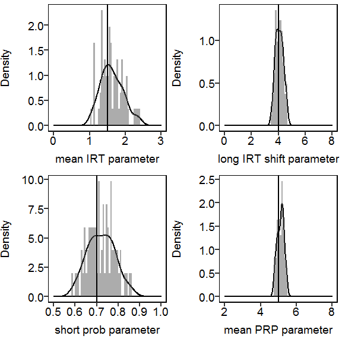

Figure 7. ABC posterior

ABC predictions

```r
if( !"predicted_ABC.RData" %in% list.files() ){
    # Simulate 2000 event records for our predictions
    set.seed(1)
    simulate_parameters = posterior_samples[ sample( 1:.N, 1000, replace = T ), names(true_parameters), with = F ]
    #Remember to change the .packages() if you are not using CAB2
    predicted_event_records = foreach( x = 1:1000, .packages = c("data.table", "CAB2")) %dopar% {
        parameters = simulate_parameters[x]
        predicted_event_record = do.call( double_exp_model, parameters )
        predicted_distributions = summary_statistics( predicted_event_record, iri = TRUE )
        # Precompute the density for the IRT and IRI distributions
        irt_density = density( predicted_distributions$irts[[1]], from = 0, n = 100 )
        prp_density = density( predicted_distributions$prps[[1]], from = 0, to = 25, n = 100 )
        iri_density = density( predicted_distributions$iris[[1]], from = 0, to = 75, n = 100 )
        list( id = x,
            irts_x = irt_density$x, irts_y = irt_density$y,
            iris_x = iri_density$x, iris_y = iri_density$y,
            prps_x = prp_density$x, prps_y = prp_density$y)
    }
    predicted_irts = rbindlist( lapply( predicted_event_records, function(x) as.data.table(x[c("id","irts_x","irts_y")]) ) )
    predicted_iris = rbindlist( lapply( predicted_event_records, function(x) as.data.table(x[c("id","iris_x","iris_y")]) ) )
    predicted_prps = rbindlist( lapply( predicted_event_records, function(x) as.data.table(x[c("id","prps_x","prps_y")]) ) )
    save( predicted_irts, predicted_iris, predicted_prps, file = "predicted_ABC.RData" )
} else{
    load( "predicted_ABC.RData" )
}
```

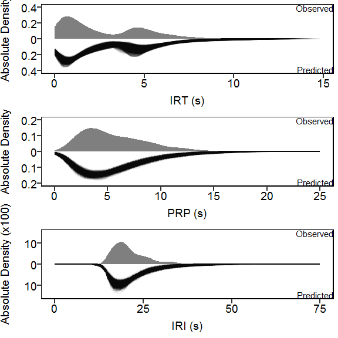

Figure 8. ABC predictions

```r
stopCluster(cl)
```